# Activity Prediction - PML Assignment

Praveen Raaj. T

22 October 2020

## Introduction

With the help of devices like Jawbone Up, Nike FuelBand, and Fitbit it is now possible to collect a large amount of data about personal activity relatively inexpensively. These type of devices are part of the quantified self movement – a group of enthusiasts who take measurements about themselves regularly to improve their health, to find patterns in their behavior, or because they are tech geeks. One thing that people regularly do is quantify how much of a particular activity they do, but they rarely quantify how well they do it.

We have used data from accelerometers to predict the manner in which the participants did their exercises. This data is given by the “classe” variable in our dataset.

## Downloading the Data

We download the training and test data from the given url.

```r
train_data_url <-"https://d396qusza40orc.cloudfront.net/predmachlearn/pml-training.csv"
test_data_url <- "https://d396qusza40orc.cloudfront.net/predmachlearn/pml-testing.csv"
train_file <- "./data/pml-training.csv"
test_file  <- "./data/pml-testing.csv"
if (!file.exists("./data")) {
  dir.create("./data")
}
if (!file.exists(train_file)) {
  download.file(train_data_url, destfile=train_file, method="curl")
}
if (!file.exists(test_file)) {
  download.file(test_data_url, destfile=test_file, method="curl")
}
```

## Getting Started

We import the modules required for this project.

```r
library(caret)
```

```r
library(rpart)
library(rpart.plot)
library(randomForest)
library(corrplot)
```

### Reading the Data

We read the downloaded training and test data as dataframes.

```r
train_raw <- read.csv("./data/pml-training.csv")
test_raw <- read.csv("./data/pml-testing.csv")
dim(train_raw)
```

```
## [1] 19622   160
```

```r
dim(test_raw)
```

```
## [1]  20 160
```

The training data contains 19622 observations and 160 variables and the test data contains 20 observations and 160 variables. We try to predict the variable “classe”.

### Data Cleaning

We clean the datasets by removing the entries with corrupted or missing data and the entries that are unnecessary.

```r
sum(complete.cases(train_raw))
```

```
## [1] 406
```

- We remove columns that contain NA missing values.

```r
train_raw <- train_raw[, colSums(is.na(train_raw)) == 0]
test_raw <- test_raw[, colSums(is.na(test_raw)) == 0]
```

- We remove of some columns that dont contribute to th prediction.

```r
classe <- train_raw$classe
train_remove <- grepl("^X|timestamp|window", names(train_raw))
train_raw <- train_raw[, !train_remove]
train_clean <- train_raw[, sapply(train_raw, is.numeric)]
train_clean$classe <- classe
test_remove <- grepl("^X|timestamp|window", names(test_raw))
test_raw <- test_raw[, !test_remove]
test_clean <- test_raw[, sapply(test_raw, is.numeric)]
```

We have now cleaned our data, the training data now contains 19622 observations with 53 columns and the test data contains 20 observations with 53 columns. The “classe” variable is included in our clean data.

### Data slicing

We split our training data into two parts, training and validation data in a 3:1 ratio.

```r
set.seed(22519)
in_train <- createDataPartition(train_clean$classe, p=0.75, list=F)
train_data <- train_clean[in_train, ]
test_data <- train_clean[-in_train, ]
```

## Data Modeling

We have used the **random forest** algorithm to fit our model. We also use **5-fold cross validation** while we apply our algorithm.

```r
control_Rf <- caret::trainControl(method="cv", 5)
model_Rf <- caret::train(classe ~ ., data=train_data , method="rf", trControl=control_Rf, ntree=10)
model_Rf
```

```
## Random Forest
##
## 14718 samples
##    52 predictor
##     5 classes: 'A', 'B', 'C', 'D', 'E'
##
## No pre-processing
## Resampling: Cross-Validated (5 fold)
## Summary of sample sizes: 11776, 11773, 11773, 11775, 11775
## Resampling results across tuning parameters:
##
##   mtry  Accuracy   Kappa
##    2    0.9764227  0.9701638
##   27    0.9865463  0.9829798
##   52    0.9753354  0.9687961
##
## Accuracy was used to select the optimal model using the largest value.
## The final value used for the model was mtry = 27.
```

We use our validation data to estimate our model’s prediction.

```r
predict_Rf <- predict(model_Rf, test_data)
confusionMatrix(factor(test_data$classe), factor(predict_Rf))
```

```
## Confusion Matrix and Statistics
##
##           Reference
## Prediction    A    B    C    D    E
##          A 1390    1    3    1    0
##          B   13  929    5    1    1
##          C    1    8  844    1    1
##          D    2    1   11  788    2
##          E    0    1    5    3  892
##
## Overall Statistics
##
##                Accuracy : 0.9876
##                  95% CI : (0.9841, 0.9905)
##     No Information Rate : 0.2867
##     P-Value [Acc > NIR] : < 2.2e-16
##
##                   Kappa : 0.9843
##
##  Mcnemar's Test P-Value : NA
##
## Statistics by Class:
##
##                      Class: A Class: B Class: C Class: D Class: E
## Sensitivity            0.9886   0.9883   0.9724   0.9924   0.9955
## Specificity            0.9986   0.9950   0.9973   0.9961   0.9978
## Pos Pred Value         0.9964   0.9789   0.9871   0.9801   0.9900
## Neg Pred Value         0.9954   0.9972   0.9941   0.9985   0.9990
## Prevalence             0.2867   0.1917   0.1770   0.1619   0.1827
## Detection Rate         0.2834   0.1894   0.1721   0.1607   0.1819
## Detection Prevalence   0.2845   0.1935   0.1743   0.1639   0.1837
## Balanced Accuracy      0.9936   0.9916   0.9848   0.9943   0.9966
```

```r
accuracy <- postResample(factor(predict_Rf), factor(test_data$classe))
accuracy[1]
```

```
##  Accuracy
## 0.9875612
```

```r
oos <- 1 - as.numeric(confusionMatrix(factor(test_data$classe), factor(predict_Rf))$overall[1])
oos
```

```
## [1] 0.01243883
```

## Test Data Prediction

We apply our trained model on the test data, that we downloaded earlier.

```r
result <- predict(model_Rf, test_clean[, -length(names(test_clean))])
result
```

```
##  [1] B A B A A E D B A A B C B A E E A B B B
## Levels: A B C D E
```

## Appendix: Figures

### 1. Correlation Matrix

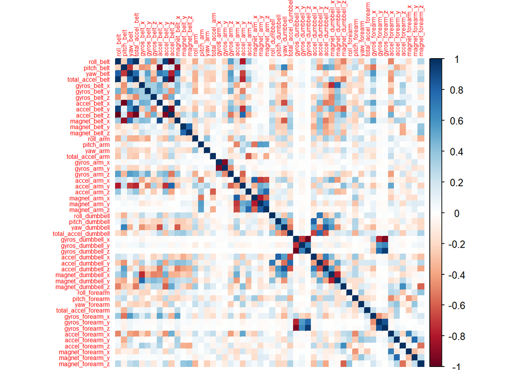

```r
cpt <- cor(train_data[, -length(names(train_data))])
corrplot(cpt, method="color", tl.cex = 0.5)
```

### 2. Decision Tree

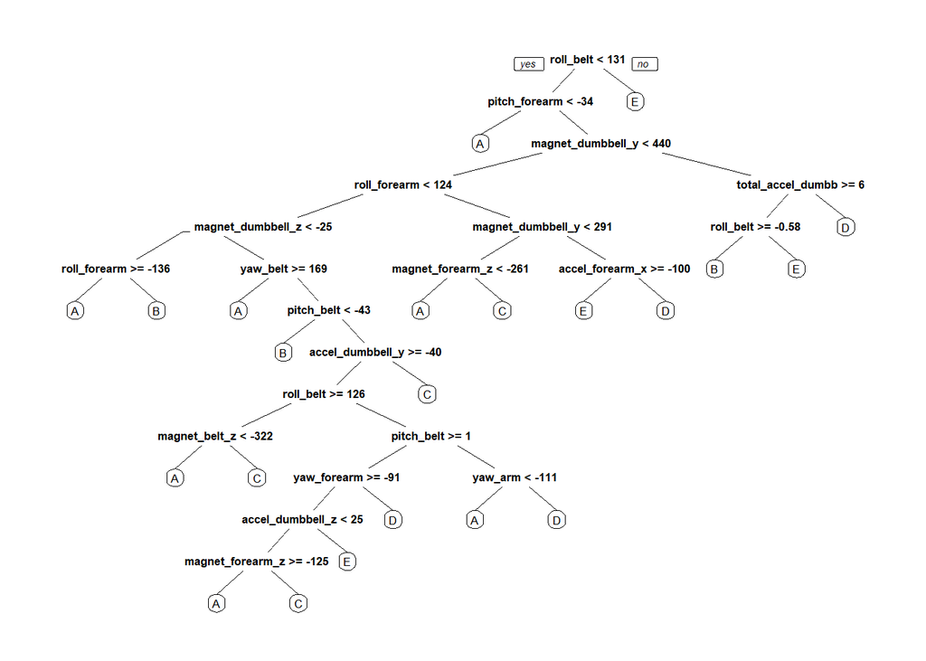

```r
tree_model <- rpart(classe ~ ., data=train_data, method="class")
prp(tree_model)
```